# DATA 605 FUNDAMENTALS OF COMPUTATIONAL MATHEMATICS

Assignment 13: Calculus

Kyle Gilde

11/26/2017

```
##           installed_and_loaded.packages.
## prettydoc                           TRUE
## Deriv                               TRUE
## rootSolve                           TRUE
## rSymPy                              TRUE
```

### 1. Use integration by substitution to solve the integral below.

$\int 4e^{-7x} dx$

```r
x <- Var("x")
sympy("integrate(4 * exp(-7 * x))")
```

```
## [1] "-4*exp(-7*x)/7"
```

### 2. Biologists are treating a pond contaminated with bacteria. The level of contamination is changing at a rate of $dN/dt = -3150/t^4 - 220$ bacteria per cubic centimeter per day, where t is the number of days since treatment began. Find a function N( t ) to estimate the level of contamination if the level after 1 day was 6530 bacteria per cubic centimeter.

```r
ft <- function(t) -3150 * t^-4 - 220
# anti-derivative

# F(t) = 1050 * t^-3 - 220 * t + C

# solve for C:

# F(1) = 6530 = 1050 * t^-3 - 220 * t + C
t <- 1
(C <- 6530 - 1050 * t^-3 + 220 * t)
```

```
## [1] 5700
```

```r
# Integral
(Ft <- function(t) 1050 * t^-3 - 220 * t + 5700)
```

```
## function(t) 1050 * t^-3 - 220 * t + 5700
```

```r
fx <- function(x) 2 * x - 9
# f(0) = 2x-9

# x = 4.5
(lower <- 4.5)
```

```
## [1] 4.5
```

```r
(upper <- lower + 4)
```

```
## [1] 8.5
```

```r
stats::integrate(Vectorize(fx), lower, upper)
```

```
## 16 with absolute error < 1.8e-13
```

### 4. Find the area of the region bounded by the graphs of the given equations.

$y = x^2 -2x -2$

$y = x + 2$

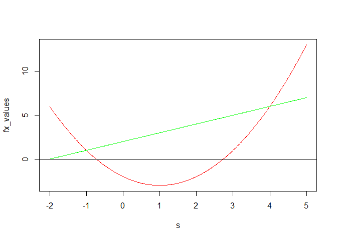

```r
s <- seq(-2, 5, by = 0.01)
fx <- function(x) x^2 - 2 * x - 2
fx2 <- function(x) x + 2

fx_values <- fx(s)
fx2_values <- fx2(s)

plot(s, fx_values, type = "l", col = "red")
lines(s, fx2_values, col = "green", type = "l")
abline(0, 0)
```

```r
# intersections
is_equal <- fx2_values == fx_values
mydf <- data.frame(cbind(s, is_equal))
intersections <- subset(mydf, is_equal == 1)

# critical points
roots <- uniroot.all(fx, c(-2, 5))
lower1 <- roots[1]
upper1 <- roots[2]
lower2 <- intersections$s[1]
upper2 <- intersections$s[2]

# answer
(integrate(Vectorize(fx2), lower2, upper2)$value - integrate(Vectorize(fx),
    lower2, upper2)$value)
```

```
## [1] 20.83333
```

```r
### Validate answer###
Fx_neg <- abs(integrate(Vectorize(fx), lower1, upper1)$value)
Fx_pos1 <- integrate(Vectorize(fx), lower2, lower1)$value
Fx_pos2 <- integrate(Vectorize(fx), upper1, upper2)$value
Fx2 <- integrate(Vectorize(fx2), lower2, upper2)$value
Fx_neg + Fx2 - Fx_pos2 - Fx_pos1
```

```
## [1] 20.83333
```

### 5. A beauty supply store expects to sell 110 flat irons during the next year. It costs $3.75 to store one flat iron for one year. There is a fixed cost of $8.25 for each order. Find the lot size and the number of orders per year that will minimize inventory costs.

```r
# lotsize = 110 / orders_per_year

# cost = lotsize*3.75 + orders_per_year * 8.25

total_cost <- function(orders_per_year) 110/orders_per_year * 3.75 + 8.25 *
    orders_per_year
(total_cost.prime <- Deriv(total_cost))
```

```
## function (orders_per_year)
## 8.25 - 412.5/orders_per_year^2
```

```r
(root <- uniroot.all(total_cost.prime, c(1, 110)))
```

```
## [1] 7.071079
```

```r
# calculate in whole number terms
orders_per_year <- floor(root)
lot_size <- ceiling(110/orders_per_year)
total_units <- orders_per_year * lot_size
min_cost <- lot_size * 3.75 + 8.25 * orders_per_year

paste(orders_per_year, "orders of", lot_size, "units each,", total_units, "total units, for a minimum cost of",
    min_cost)
```

```
## [1] "7 orders of 16 units each, 112 total units, for a minimum cost of 117.75"
```

### 6. Use integration by parts to solve the integral below.

$\int ln( 9x ) * x^6 dx$

```r
x <- Var("x")
sympy("integrate(log( 9 * x ) * x**6)")
```

```
## [1] "x**7*log(9)/7 + x**7*log(x)/7 - x**7/49"
```

### 7. Determine whether f ( x ) is a probability density function on the interval [1, e^6] . If not, determine the value of the definite integral.

$f ( x ) = 1/6x$

```r
fx <- function(x) 1/(6 * x)
lower <- 1
upper <- exp(6)

all.equal(1, integrate(Vectorize(fx), lower, upper)$value, tolerance = 10^-8)
```

```
## [1] TRUE
```